# WritingSSfiles

Christine Stawitz

May 14, 2019

## Introduction

This page discusses reading in an existing stock assessment file and replacing the data values with those from the `atlantisom` package. To read in the Stock Synthesis files, first ensure you have the latest version of `r4ss`. You will need to ensure the relevant Stock Synthesis files are stored in the inst/extdata/ folder, with each species example in its own folder.

```r
devtools::install_github("r4ss/r4ss", dependencies = FALSE)
```

## Sardine example

Dummy files are in the package directory; use `r4ss` to load the dummy data file. Use the relevant species config file to load the configuration variables for each run. Note: this script will extract conditional age-at-length data, length composition data, and a CPUE in biomass for one survey during the specified time interval, and age composition data, length composition data, and catch in numbers from a single fishery. The timing and duration of the survey and fishery should be set in the config file. Unless otherwise stated, numbers going into Stock Synthesis are in thousands of fish. Weight of a single fish is in grams or kilograms, and weight of biomass is in metric tons. We assume a single sex model with a sex ratio fixed at 0.5 - different assumptions require modifying the Stock Synthesis control file. This script only runs with Stock Synthesis 3.30.

```
## Running SS_readdat_3.30
```

```
## SS_readdat_3.30 - read version = 3.30
```

```
## use_meanbodywt (0/1): 0
```

```
## N_lbinspop:
```

```
## use_lencomp (0/1): 1
```

```
## N_lbins: 45
```

```
## N_agebins: 10
```

```
## use_MeanSize_at_Age_obs (0/1): 0
```

```
## N_environ_variables: 0
```

```
## Read of data file complete. Final value = 999
```

```r
names(stocksynthesis.data$catch) <- names(stocksynthesis.data$CPUE)

stocksynthesis.data$CPUE
```

```
##    year seas index    obs se_log
## 1    30    7     2 474849    0.1
## 2    31    7     2 435870    0.1
## 3    32    7     2 464053    0.1
## 4    33    7     2 548864    0.1
## 5    34    7     2 424040    0.1
## 6    35    7     2 481492    0.1
## 7    36    7     2 461319    0.1
## 8    37    7     2 450456    0.1
## 9    38    7     2 515847    0.1
## 10   39    7     2 482477    0.1
## 11   40    7     2 401372    0.1
## 12   41    7     2 446629    0.1
## 13   42    7     2 408634    0.1
## 14   43    7     2 433813    0.1
```

[output cut: 36 more lines]

We can next look at age composition data

```r
stocksynthesis.data$agecomp
```

```
##      Yr Seas FltSvy Gender Part Ageerr Lbin_lo Lbin_hi  Nsamp     a1
## 1    30    7      2      0    0      1      10      11  0.002  0.002
## 2    30    7      2      0    0      1      11      12 0.0131 0.0131
## 3    30    7      2      0    0      1      12      13 0.0394 0.0394
## 4    30    7      2      0    0      1      13      14 0.0627 0.0627
## 5    30    7      2      0    0      1      14      15 0.0616 0.0586
## 6    30    7      2      0    0      1      15      16 0.0445 0.0344
## 7    30    7      2      0    0      1      16      17 0.0375 0.0142
## 8    30    7      2      0    0      1      17      18 0.0414  0.004
## 9    30    7      2      0    0      1      18      19 0.0455  0.001
## 10   30    7      2      0    0      1      19      20 0.0394      0
## 11   30    7      2      0    0      1      20      21 0.0314      0
## 12   30    7      2      0    0      1      21      22 0.0273      0
## 13   30    7      2      0    0      1      22      23 0.0273      0
## 14   30    7      2      0    0      1      23      24 0.0293      0
```

[output cut: 4305 more lines]

```r
stocksynthesis.data$lencomp
```

```
##     Yr Seas FltSvy Gender Part Nsamp l10 l11 l12 l13 l14 l15 l16 l17 l18
## 1   30    7      2      0    0   989   2  13  39  62  61  44  37  41  45
## 2   31    7      2      0    0   990   2  14  42  67  65  46  38  41  44
## 3   32    7      2      0    0   990   2  12  38  61  60  43  35  41  46
## 4   33    7      2      0    0   995   2  13  40  64  62  43  34  39  44
## 5   34    7      2      0    0   994   2  11  36  58  57  40  33  37  44
## 6   35    7      2      0    0   984   2  14  44  70  68  47  37  43  48
## 7   36    7      2      0    0   991   2  11  36  57  55  41  35  42  47
## 8   37    7      2      0    0   993   2  13  40  64  61  45  37  42  46
## 9   38    7      2      0    0   997   2  13  41  65  63  44  36  40  42
## 10  39    7      2      0    0   997   2  13  40  63  61  43  36  38  42
## 11  40    7      2      0    0   996   2  13  42  66  64  46  36  41  44
## 12  41    7      2      0    0   994   2  12  38  60  57  43  36  43  46
## 13  42    7      2      0    0   989   2  13  41  65  63  46  40  44  47
## 14  43    7      2      0    0   987   2  12  37  59  57  42  36  41  44
```

[output cut: 389 more lines]

We may also need to access or modify the setup variables before the data matrices.

```r
#CPUE units, SD and error structure
stocksynthesis.data$CPUEinfo
```

```
##         Fleet Units Errtype SD_Report
## Fishery     1     2       0         0
## Survey      2     1       0         0
```

```r
#Number of length bins
stocksynthesis.data$N_lbins
```

```
## [1] 45
```

```r
#Length bin method
stocksynthesis.data$Lbin_method
```

```
## [1] 3
```

```r
#Vector of age bins
stocksynthesis.data$agebin_vector
```

```
##  [1]  1  2  3  4  5  6  7  8  9 10
```

## Writing index data

```r
results <- get(load(atlantis_output_name))
devtools::load_all()
```

```
## Loading atlantisom
```

```r
species=c(species)

#Sample all boxes
boxes <- unique(results$nums$polygon)

#Efficiency of the survey
effic <- data.frame(species=species, efficiency=eff_case)

# Assume uniform selectivity
sel<- data.frame(species=rep(species,length(age_classes)),
               agecl=age_classes,
              selex=sel_by_age)

#Sample survey - 3rd timestep simulates a summer survey
survey_out <- create_survey(dat=results$nums, time=survey_sample_full, species=species, boxes=boxes, effic=effic, selex=sel)

#Set effective sample size for age compositions
effN <- surveyEffN
highEffN <- data.frame(species=species, effN=rep(effN, length(species)))

#Sample fish for age composition
age_comp_data <- sample_fish(survey_out, highEffN)

# aggregate true resn per survey design
survey_aggresnstd <- aggregateDensityData(dat = results$resn,
                                          time = unique(results$nums$time),
                                          species = species,
                                          boxes = boxes)

# aggregate true structn per survey design
survey_aggstructnstd <- aggregateDensityData(dat = results$structn,
                                             time = unique(results$nums$time),
                                             species = species,
                                             boxes = boxes)

ss_structnstd <- sample_fish(survey_aggstructnstd,
                             effN,
                             sample=FALSE)
ss_resnstd <- sample_fish(survey_aggresnstd,
                          effN,
                          sample=FALSE)

#Extract length composition data
ss_length_stdsurv <- calc_age2length(structn = ss_structnstd,
                                     resn = ss_resnstd,
                                     nums = age_comp_data,
                                     biolprm = results$biolprm, fgs = results$fgs,
                                     CVlenage = CVs$lenage, remove.zeroes=TRUE)

#Need to replace with interp function
wtAtAge <- ss_length_stdsurv$muweight %>%
  select(species, agecl, time, wtAtAge = atoutput) %>%
  mutate(wtAtAge = wtAtAge/1000)
# CV function
cv <- data.frame(species="Pacific_sardine", cv=CVs$survey)

#Sample survey biomass
survObsBiom <- sample_survey_biomass(dat=survey_out,cv=cv,wtAtAge)
```

## Catch data

```r
catch_numbers <-  create_fishery_subset(dat = results$catch,
                                         time = fish_years,
                                         species = species,
                                         boxes = boxes)

#Sample catch in numbers
catch_total <- catch_numbers %>%
  group_by(time) %>%
  summarise(catch=sum(atoutput))

#Test writing CPUE in biomass
  stocksynthesis.data <- SS_write_ts(ss_data_list = stocksynthesis.data,
                ts_data = list(survObsBiom$atoutput[fish_years],
                  catch_total$catch[catch_total$time==fish_years]),
                CVs = c(CVs$survey,
                        CVs$fishery),
                data_years = list((survObsBiom$time[fish_years]-survey_sample_time)/timestep+1,             fish_years),
            sampling_month = list(rep(survey_month,nyears),
                                rep(fishing_month,nyears)),
                units = c("biomass","numbers"),
                data_type=c("CPUE","catch"),
                fleets = c(2,1))
```

## Writing age composition data

```r
age_comp_data
```

```
##             species agecl polygon layer time atoutput
## 1   Pacific_sardine     1      NA    NA    3       79
## 2   Pacific_sardine     2      NA    NA    3      423
## 3   Pacific_sardine     3      NA    NA    3      243
## 4   Pacific_sardine     4      NA    NA    3      107
## 5   Pacific_sardine     5      NA    NA    3       65
## 6   Pacific_sardine     6      NA    NA    3       42
## 7   Pacific_sardine     7      NA    NA    3       13
## 8   Pacific_sardine     8      NA    NA    3       19
## 9   Pacific_sardine     9      NA    NA    3        7
## 10  Pacific_sardine    10      NA    NA    3        2
## 11  Pacific_sardine     1      NA    NA    8      484
## 12  Pacific_sardine     2      NA    NA    8       43
## 13  Pacific_sardine     3      NA    NA    8      242
## 14  Pacific_sardine     4      NA    NA    8      117
```

[output cut: 976 more lines]

```r
#Get the age bins
age_bin_names <- names(stocksynthesis.data$agecomp)[10:length(names(stocksynthesis.data$agecomp))]
age_bins <- sub("a","",age_bin_names)

age_comp_flat <- reformat_compositions(age_comp_data,
                     round.places = 4,
                     comp_type = "agecomp")

## Write age composition data for survey
stocksynthesis.data <- SS_write_comps(ss_data_list = stocksynthesis.data,
               comp_matrix = list(age_comp_flat[burnin:(burnin+nyears-1),]),
               data_rows = list(stocksynthesis.data$styr:(stocksynthesis.data$styr+nyears-1)),
               sampling_month = list(rep(survey_month,nyears)),
               data_type = c("agecomp"),
               fleet_number = c(1),
               bins = list(age_bins),
               caal_bool = c(FALSE))
stocksynthesis.data$agecomp
```

```
##    Yr Seas FltSvy Gender Part Ageerr Lbin_lo Lbin_hi Nsamp    a1    a2
## 1   1    7      1      0    0      1      -1      -1     1 0.227 0.181
## 2   2    7      1      0    0      1      -1      -1     1 0.222 0.211
## 3   3    7      1      0    0      1      -1      -1     1 0.253 0.201
## 4   4    7      1      0    0      1      -1      -1     1 0.226 0.221
## 5   5    7      1      0    0      1      -1      -1     1  0.24 0.189
## 6   6    7      1      0    0      1      -1      -1     1 0.229 0.213
## 7   7    7      1      0    0      1      -1      -1     1 0.223 0.192
## 8   8    7      1      0    0      1      -1      -1     1 0.236 0.198
## 9   9    7      1      0    0      1      -1      -1     1 0.239 0.206
## 10 10    7      1      0    0      1      -1      -1     1 0.218 0.182
## 11 11    7      1      0    0      1      -1      -1     1 0.246 0.199
## 12 12    7      1      0    0      1      -1      -1     1 0.235 0.225
## 13 13    7      1      0    0      1      -1      -1     1 0.235 0.202
## 14 14    7      1      0    0      1      -1      -1     1 0.242 0.184
```

[output cut: 87 more lines]

```r
#We end up using CAAL for the survey below, so let's generate fishery age comps instead
effN <- data.frame(species=species, effN=effN)

catch_numssshigh <- sample_fish(catch_numbers, effN)

#Get weights
# aggregate true resn per survey or fishery subset design
catch_aggresnss <- aggregateDensityData(dat = results$resn,
                                 time = c(0:111),
                                 species = species,
                                 boxes = boxes)

# aggregate true structn per survey or fishery subsetdesign
catch_aggstructnss <- aggregateDensityData(dat = results$structn,
                                 time = c(0:111),
                                 species = species,
                                 boxes = boxes)

#dont sample these, just aggregate them using median
catch_structnss <- sample_fish(catch_aggstructnss, effN, sample = FALSE)

catch_resnss <-  sample_fish(catch_aggresnss, effN, sample = FALSE)

str(catch_numssshigh)
```

```
## 'data.frame':    500 obs. of  6 variables:
##  $ species : Factor w/ 1 level "Pacific_sardine": 1 1 1 1 1 1 1 1 1 1 ...
##  $ agecl   : num  1 2 3 4 5 6 7 8 9 10 ...
##  $ polygon : logi  NA NA NA NA NA NA ...
##  $ layer   : logi  NA NA NA NA NA NA ...
##  $ time    : int  30 30 30 30 30 30 30 30 30 30 ...
##  $ atoutput: int  134 110 231 167 113 75 64 43 35 28 ...
```

```r
catch_length <- calc_age2length(structn = catch_structnss,
                                 resn = catch_resnss,
                                 nums = catch_numssshigh,
                                 biolprm = results$biolprm, fgs = results$fgs,
                                 maxbin = maxbin,
                                 CVlenage = CVs$lenage, remove.zeroes=TRUE)
```

## Setting up EM

```r
#Check length compositions match age compositions
ss_length_stdsurv$natlength %>%
  group_by(time,agecl) %>%
  summarise(sum(atoutput))
```

```
## # A tibble: 976 x 3
## # Groups:   time [?]
##     time agecl `sum(atoutput)`
##    <int> <dbl>           <dbl>
##  1     3     1              78
##  2     3     2             421
##  3     3     3             242
##  4     3     4             107
##  5     3     5              64
##  6     3     6              42
##  7     3     7              10
##  8     3     8              19
##  9     3     9               7
## 10     8     1             483
## # ... with 966 more rows
```

```r
len_comp_data <- ss_length_stdsurv$natlength
fish_len_comp_data <- catch_length$natlength
```

Once we have the natlength matrix, we can munge the data into the proper CAAL and length bin format for SS

```r
caal_comp_flat <- reformat_compositions(len_comp_data,                                round.places=4,
                comp_type="caalcomp")


#remove burnin
caal_comp_final <- filter(caal_comp_flat,
                         time %in% survey_years)


#Add over age classes to get sample size
len_comp_flat <- reformat_compositions(len_comp_data,
                                  round.places = 0,
                           comp_type="lencomp")
#remove burnin
len_comp_final <- filter(len_comp_flat,
                         time %in% survey_years)

length_bins <- as.integer(names(len_comp_final))
length_bins <- length_bins[!is.na(length_bins)]

fish_len_comp_flat <- reformat_compositions(catch_length$natlength,
                                  round.places = 0,
                           comp_type="lencomp")
#remove burnin
fish_len_comp_final <- filter(fish_len_comp_flat,
                         time %in% fish_years)

fish_age_comp_flat <- reformat_compositions(catch_numssshigh,
                           comp_type="agecomp")
#remove burnin
fish_age_comp_final <- filter(fish_age_comp_flat,
                         time %in% fish_years)

comp_list <- list(caal_comp_final,len_comp_final,          fish_age_comp_final, fish_len_comp_final)

apply_month <- list(rep(survey_month, nrow(comp_list[[1]])), rep(survey_month, nrow(comp_list[[2]])), rep(fishing_month,nrow(comp_list[[3]])),rep(fishing_month,nrow(comp_list[[4]])))

# Write CAAL and length composition data
stocksynthesis.data <- SS_write_comps(ss_data_list = stocksynthesis.data, comp_matrix = comp_list, data_rows = list((comp_list[[1]]$time-survey_sample_time)/timestep + 1 ,(survey_years-survey_sample_time)/timestep + 1,fish_years,fish_years),
        sampling_month = apply_month, data_type = rep(c("agecomp", "lencomp"),2), fleet_number = c(2,2,1,1),  bins = list(age_bins, length_bins, age_bins, length_bins), caal_bool = c(TRUE, rep(FALSE,3)))

head(stocksynthesis.data$lencomp)
```

```
##   Yr Seas FltSvy Gender Part Nsamp l10 l11 l12 l13 l14 l15 l16 l17 l18 l19
## 1 30    7      2      0    0   991   2  13  39  62  59  43  35  37  41  35
## 2 31    7      2      0    0   989   2  12  38  61  58  43  37  42  46  42
## 3 32    7      2      0    0   989   2  14  43  69  66  47  36  39  43  40
## 4 33    7      2      0    0   988   2  12  38  61  60  43  36  40  47  44
## 5 34    7      2      0    0   991   2  13  40  65  62  43  33  35  40  38
## 6 35    7      2      0    0   992   2  12  39  62  60  43  35  39  45  42
##   l20 l21 l22 l23 l24 l25 l26 l27 l28 l29 l30 l31 l32 l33 l34 l35 l36 l37
## 1  28  25  28  31  34  34  33  32  30  29  28  26  26  24  24  23  21  22
## 2  33  27  25  28  31  31  31  29  27  26  25  25  25  24  24  24  20  21
## 3  32  25  24  27  30  31  31  30  28  27  27  28  26  24  22  21  19  18
## 4  36  28  25  28  30  32  33  30  29  26  26  25  24  24  21  21  19  19
## 5  31  25  22  25  28  30  31  30  28  28  28  27  27  24  23  22  21  20
## 6  34  26  24  26  28  30  30  30  28  27  27  25  25  23  22  21  20  19
##   l38 l39 l40 l41 l42 l43 l44 l45 l46 l47 l48 l49 l50 l51 l52 l53 l54
## 1  19  18  16  15  13  11   9   8   5   4   4   3   2   0   0   0   0
## 2  20  18  16  16  13  11   9   8   6   4   4   3   3   1   0   0   0
## 3  17  16  15  13  11   9   9   8   6   4   4   3   3   1   1   0   0
## 4  17  16  16  14  13  10   9   9   7   6   4   3   3   2   0   0   0
## 5  21  19  17  15  14  12  11  10   9   6   4   4   3   3   1   1   0
## 6  18  18  16  15  14  13  11  10   9   7   5   4   3   3   1   1   0
```

```r
head(stocksynthesis.data$agecomp)
```

```
##   Yr Seas FltSvy Gender Part Ageerr Lbin_lo Lbin_hi  Nsamp     a1     a2
## 1 30    7      2      0    0      1      10      11  0.002  0.002      0
## 2 30    7      2      0    0      1      11      12 0.0131 0.0131      0
## 3 30    7      2      0    0      1      12      13 0.0394 0.0394      0
## 4 30    7      2      0    0      1      13      14 0.0626 0.0626      0
## 5 30    7      2      0    0      1      14      15 0.0595 0.0575  0.002
## 6 30    7      2      0    0      1      15      16 0.0434 0.0343 0.0091
##   a3 a4 a5 a6 a7 a8 a9 a10
## 1  0  0  0  0  0  0  0   0
## 2  0  0  0  0  0  0  0   0
## 3  0  0  0  0  0  0  0   0
## 4  0  0  0  0  0  0  0   0
## 5  0  0  0  0  0  0  0   0
## 6  0  0  0  0  0  0  0   0
```

```r
#Change length bin structure to match atlantis data
stocksynthesis.data$lbin_vector <- length_bins

#Set lbin_method to 1 - this makes the population length bins match the data bins
#When lbin_method==1, we just comment out the binwidth, minimum, and maximum size arguments since they aren't used
stocksynthesis.data$lbin_method <- 1
stocksynthesis.data$binwidth <- "#"
stocksynthesis.data$minimum_size <- "#"
stocksynthesis.data$maximum_size <- "#"

#Change minimum sample size to 0.001 for CAAL data (SS won't let it go lower than this)
stocksynthesis.data$age_info$minsamplesize <- rep(0.001,2)

SS_writedat(stocksynthesis.data, outfile = paste0("./inst/extdata/",model_dir,
datfile_name),
                 overwrite=TRUE)
```

```
## running SS_writedat
```

```
## running SS_writedat_3.30
```

```
## opening connection to ./inst/extdata/Sardine_SS_files/sardEM_3_3.dat
```

```
## file written to ./inst/extdata/Sardine_SS_files/sardEM_3_3.dat
```

## Coming up with dynamic life history parameters

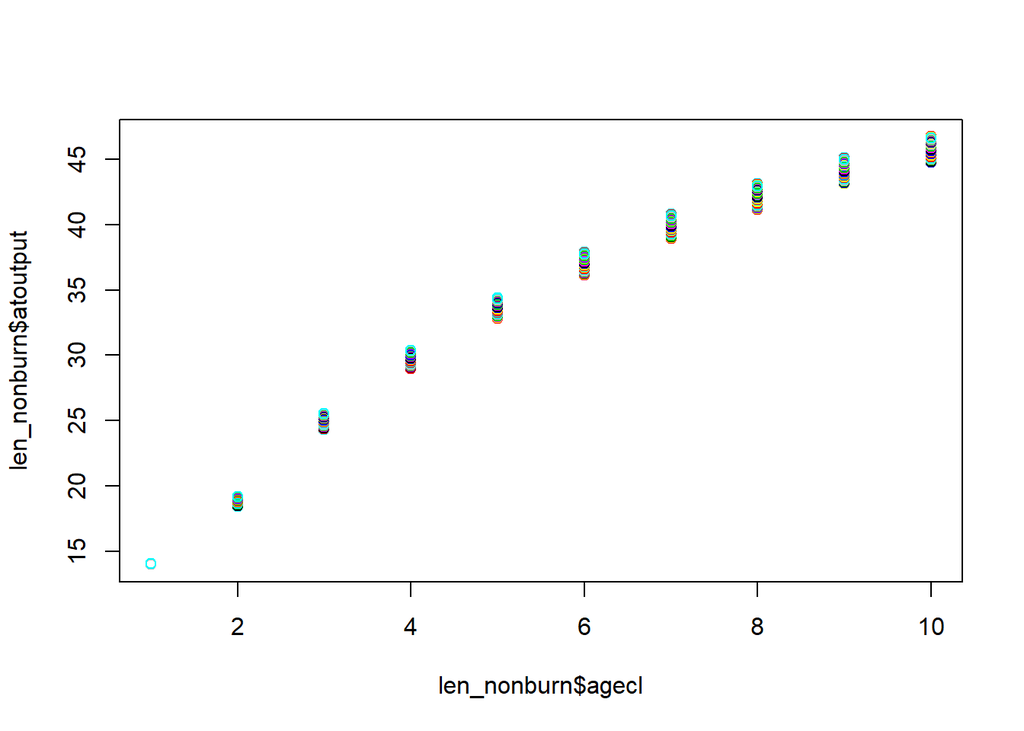

```r
#Get biological parameters
biolprm <- results$biolprm
fgs <- results$fgs
li_a_use <- biolprm$wl[match(fgs$Code[match(species,fgs$Name)],biolprm$wl[, 1]), 2]/1000
li_b_use <- biolprm$wl[match(fgs$Code[match(species,fgs$Name)],biolprm$wl[, 1]), 3]


len_nonburn <- ss_length_stdsurv$mulen %>%
  filter(time > burnin*timestep)
plot(len_nonburn$atoutput~len_nonburn$agecl, col=len_nonburn$time)
```

```r
length.data <- data.frame("Year"=(len_nonburn$time-survey_sample_time)/timestep+1, length=len_nonburn$atoutput, Weight=NA, Sex="Female", age=as.integer(len_nonburn$agecl))

#require(bbmle)
#vb_estimates <-sample_fit_vbgf(length.data, 25, 45, 0.4,
#  0.1, 0.1, 20, 40, 0.05, 0.01, 0.01,
#  30, 50, 0.6, 0.3, 0.3, 0.5, 10)
```

## Running stock synthesis

After the data and control file modifications, ensure you copy the local SS 3.3 executable into the folder containing the model files. Then run the following chunk.

```r
#Run stock synthesis model
run_stocksynthesis(species = species, model_dir = model_dir, show_output = TRUE)
```

```
## Running ss EM for species: Pacific_sardine
```